# Land Size Distribution Analysis

## Primary Questions Are

- Are there differences between locations in mean land size?
- Is land-size important for determining food security or incomes?
- How much does land size vary in one single location?
- Does predicting the mean, or the median actually tell us anything?
- Can we interactively plot the marginal distribution of land-size, given parameters in a given location?
- If so, can we combine this with census data to answer the question: *based on the data we have, we think there are N farmers with farm-sizes under X ha, with confidence y*
- How would we validate such a model?

## Setup

First lets load the packages that we will need:

```r
knitr::opts_chunk$set(warning = FALSE, message = FALSE)
# Data Processing Packages
library(jsonlite)
library(readr)
library(dplyr)
library(tibble)
library(rlang)

# Spatial Packages
library(sf)
library(sp)
library(stars)

# Plotting Packages
library(corrplot)
library(ggplot2)

# Statistical Analysis Pakcages
library(FactoMineR) # Package for dimensionality reduction
library(factoextra) # Package for dimensionality reduction
library(brms) # Bayesian analysis package
library(rstan) # R package for writing stan models
library(lme4) # Linear, generalised linear, and nonlinear mixed models
library(mgcv) # Package for GAMs
library(lqmm) # Linear Quatile Mixed Models (Hierarchical Quantile)
library(quantreg) # Quantile Regression
library(bamlss) # Bayesian Additive Models for Location Scale and Shape
```

Then lets load the data:

```r
rhomis_df <- readr::read_csv("./data/prepared-data/rhomis-geo-data.csv")

# Here we create a "geographic copy" of the dataset
rhomis_geo_data <- sf::st_as_sf(x = rhomis_df, wkt = "geometry")
rhomis_geo_data <- rhomis_geo_data[rhomis_geo_data$iso_3!="NER",]

# IPUMS GEO2 level dataset
ipums_df <- readr::read_csv("./data/prepared-data/ipums-all.csv")
ipums_geo <- sf::st_as_sf(x = ipums_df, wkt = "geometry")
ipums_geo <- ipums_geo[ipums_geo$iso_3!="NER",]


# lsms_all <- readr::read_csv("./data/prepared-data/lsms-all.csv")

# There are a lot of variables to examine in the dataset,
# in this file we have organised them into categories
variable_categories <- jsonlite::read_json("./data/variable-categorisation.json")


world_all <- readr::read_csv("./data/prepared-data/world-shapefile.csv")
world_all <- sf::st_as_sf(x = world_all, wkt = "geometry")
```

So what are these datasets? `rhomis_df` is a set of RHoMIS indicators, with their GPS coordinates. These indicators have been linked to subnational level (GEO2) IPUMS census data.

# Computing Indicators

There are many indicators in the RHoMIS dataset, however, we might want to compute some further indicators.

All of the income units come in local currency units. I would like currencies to be internationally comparable, so I am going to change them to PPP$ (purchasing power parity).

```r
income_columns_lcu <- c(
  "crop_income_lcu_per_year",
  "livestock_income_lcu_per_year",
  "total_income_lcu_per_year",
  "off_farm_income_lcu_per_year",
  "value_crop_consumed_lcu_per_hh_per_year",
  "value_livestock_products_consumed_lcu_per_hh_per_year",
  "value_farm_products_consumed_lcu_per_hh_per_year"
)
income_columns_ppp <- gsub("lcu", "ppp", income_columns_lcu)
rhomis_df[income_columns_ppp] <- rhomis_df[income_columns_lcu]/rhomis_df$currency_conversion_lcu_to_ppp

# Population columns came in form of totals
# Convert these into percentages for comparison
# between locations

population_columns_percentage <- paste0(
  variable_categories$ipums$population_columns,
  "_perc"
)

ipums_df[population_columns_percentage] <- 100*ipums_df[unlist(variable_categories$ipums$population_columns)]/ipums_df$TOTPOP_GEO2A



# There are duplicate GEOID's by country, so need to create country specific IDs

ipums_df$GEOID_country <- paste0(ipums_df$GEOID, "_" ,ipums_df$iso_2)
rhomis_df$GEOID_country <- paste0(rhomis_df$GEOID, "_" ,rhomis_df$iso_2)


# It can be useful, for exploration, to understand the
# different countries by region.

region_table <- tibble::as_tibble(
  list(
    "iso_2"=c("BF",
              "ET",
              "GH",
              "KE",
              "ML",
              "NG",
              "RW",
              "TZ",
              "UG"),
    "region_afr"=c("west_africa",
                   "east_africa",
                   "west_africa",
                   "east_africa",
                   "west_africa",
                   "west_africa",
                   "central_africa",
                   "east_africa",
                   "east_africa"


                   )
  )
)

ipums_df <- ipums_df %>% left_join(region_table, by = "iso_2")
rhomis_df <- rhomis_df %>% left_join(region_table, by = "iso_2")
```

## Assessing Data Coverage and Completeness

We are interested in the distribution of farm characteristics at the subnational level. To assess a “distribution”, we would need a sufficient number of households.

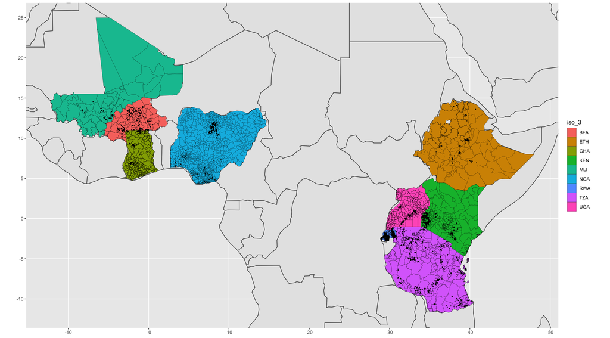

[figure not shown]

[figure not shown]

[figure not shown]

```r
ggplot() +
  geom_sf(data=world_all, size=0.5) +
  geom_sf(data=ipums_geo, color="black", size=0.1,aes(fill=iso_3))  +
  geom_sf(data=rhomis_geo_data, size=0.1) +
  coord_sf(xlim = c(bounding_box$xmin, bounding_box$xmax), ylim = c(bounding_box$ymin, bounding_box$ymax))
```

## Country Selection

Based on the plots above, there are three candidates from the dataset which have helpfule characteristics:

1. They have a relatively large number of surveys (n>2000)
2. They have surveys in a significant portion of their subnational areas (>40%)

The three countries are Burkina Faso (West Africa), Rwanda (Central Africa), and Tanzania (East Africa).

# What Can Land Size Tell Us

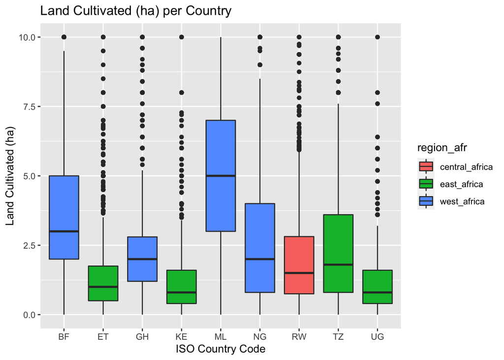

```r
land_size_df <- rhomis_df %>%
  filter(!is.na(iso_2))


ggplot(land_size_df, aes(x=iso_2, y=land_cultivated_ha, fill=region_afr))+
  geom_boxplot()+
    scale_y_continuous(limits = quantile(rhomis_df$land_cultivated_ha, c(0, 0.95), na.rm = T))+
  labs(title="Land Cultivated (ha) per Country",
        x ="ISO Country Code", y = "Land Cultivated (ha)")
```

Here we see that we have a wide range of land size distributions, each of which vary quite significantly by country.

### Land Size Correlations

As mentioned, land size could provide important information on poverty levels or food security

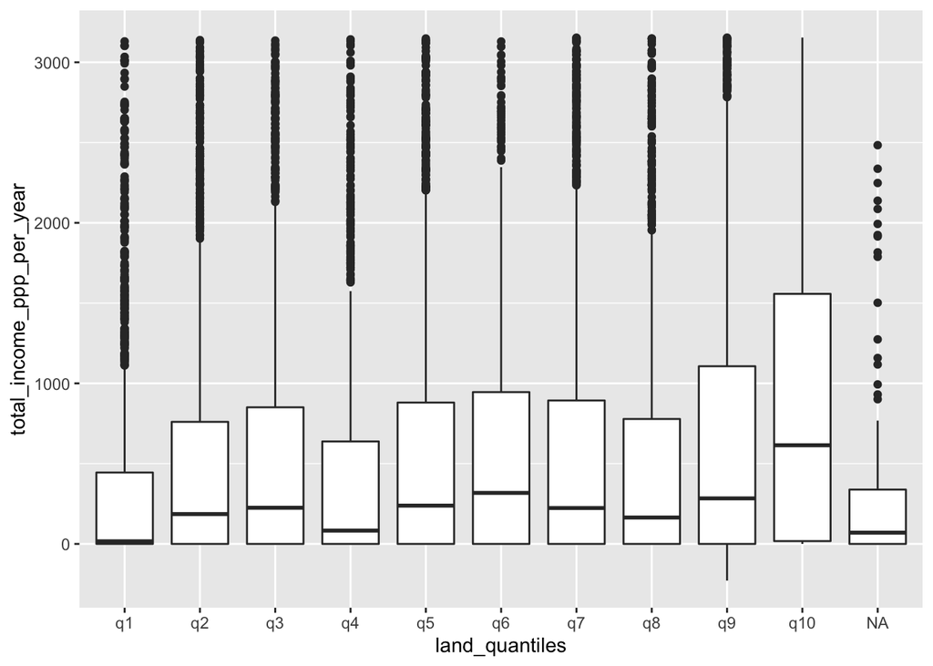

```r
rhomis_no_na <- rhomis_df %>%
  filter(!is.na(iso_2)) %>%
    filter(!is.na(land_cultivated_ha))


bin_number <- 10
land_quartiles <- quantile(rhomis_df$land_cultivated_ha, seq(0,1,1/bin_number), na.rm=T)

x_gt_cond <- land_quartiles[1:(length(land_quartiles)-1)]
x_ls_cond <- land_quartiles[2:length(land_quartiles)]
x_quarts <- paste0("q",c(1:bin_number))
cases <- paste0('land_cultivated_ha >= ', x_gt_cond, ' & land_cultivated_ha < ', x_ls_cond, ' ~ "', x_quarts, '"')


rhomis_no_na <- rhomis_df %>% mutate(land_quantiles = dplyr::case_when(!!!rlang::parse_exprs(cases)))
rhomis_no_na$land_quantiles <- factor(rhomis_no_na$land_quantiles, levels=x_quarts, ordered=T)



ggplot(rhomis_no_na, aes(x=land_quantiles, y=total_income_ppp_per_year)) +
  geom_boxplot()+
  scale_y_continuous(limits = quantile(rhomis_no_na$total_income_ppp_per_year, c(0, 0.8), na.rm = T))
```

# Subnational Level Covariates

```r
variable_categories$ipums$economic_subnational_indicators
```

```
## [[1]]
## [1] "TELEPHONE_GEO2A"
##
## [[2]]
## [1] "TOILETHH_GEO2A"
##
## [[3]]
## [1] "DIRTFLOOR_GEO2A"
##
## [[4]]
## [1] "ELECTRICITY_GEO2A"
##
## [[5]]
## [1] "RENTERS_GEO2A"
##
## [[6]]
## [1] "HOMEOWNERS_GEO2A"
##
## [[7]]
## [1] "URBANIZ_GEO2A"
```

```r
rhomis_no_na$DIRTFLOOR_GEO2A
```

[output not shown]

[output cut: 3459 more lines]